[figure not shown]

# [Ahmet Kaya **Data Science Blog**](https://ahmtkaya.github.io/)

# An Analysis of Variables' Coefficients Effect on the ML Regression Models' Accuracy

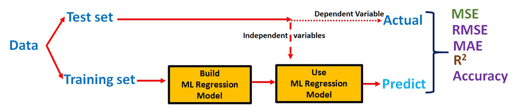

```python
from PIL import Image
Image.open("MLRegession.jpg")
```

R-squared **$(R^2)$**, Mean Squared Error **(MSE)**, Mean Absolute Error **(MAE)** and Root mean squared error **(RMSE)** are the most commonly used metrics to measure accuracy for continuous variables. In this post we will observe the **coefficient of variables (CoV)** effect on the **MAE**, **MSE**, $R^2$, and **accuracy**. We will apply the same linear regression to **4** different **data** which has variables with diferent coficients to explain to explain how and why the **MSE, MAE, $R^2$, and Accuracy** are changing. First, while we keep the **MSE** and **MAE** fixed, we will observe the $R^2$ and **accuracy** with the change of **coefficient of variables**. Secondly, while we keep the $R^2$, and **accuracy** fixed, we will observe the **MSE** and **MAE** with the change of **coefficient of variables**.

```python
import numpy as np
import pandas as pd
import matplotlib.pyplot as plt
import seaborn as sns
from itertools import count
from sklearn import metrics
import statsmodels.api as sm
from sklearn.linear_model import LinearRegression
%matplotlib inline
```

# 1. Constant MSE and Increasing $R^2$

We will create 4 diferent data (D1, D2, D3, D4) with different coefficient variables. First, while we keep the **MSE** and **MAE** fixed for D1, D2, D3 and D4, while the coefficient of variables values will be 0.1, 0.5, 1, 10 for D1, D2, D3 and D4 respectively

# Data1 (D1): $Y=0.1+0.1*X_1+0.1*X_2+0.1*X_3+(Random Error)$

While the constant number and coefficient of variables (CoV) are 0.1, we will add the random error which has the coefficient of error(CoE)=0.1. We will see how $accuracy$ and $R^2$ will be affected with $CoE=0.1/CoV=0.1$ rate.

# Data2 (D2): $Y=0.5+0.5*X_1+0.5*X_2+0.5*X_3+(Random Error)$

While the constant number and CoV are 0.5, and we will add the random error which has the CoE=0.1. Observation for the $accuracy$ and $R^2$ with affect of the $CoE=0.1/CoV=0.5$ rate.

# Data3 (D3): $Y=1+1*X_1+1*X_2+1*X_3+(Random Error)$

While the constant number and coefficient are 1, we will add the random error which has the CoE= 0.1. How will $accuracy$ and $R^2$ be affected with $CoE=0.1/CoV=1$ rate?. Answer is $CoE=0.1/CoV=1$ rate.

# Data4 (D4): $Y=10+10*X_1+10*X_2+10*X_3+(Random Error)$

While the constant number and coefficient are 10, we will add the random errorwhich has the CoE=0.1.

```python
input_dim = 3
output_dim = 1
size = 1000
total_size = size * input_dim
rand_state = np.random.RandomState(42)
X = np.array([rand_state.rand() for i in range(total_size)], dtype=np.float32)
X = X.reshape(-1, input_dim)
#coefficients
coeff=[]
alfa=[0.1, 0.5, 1, 10]
for i in alfa:coeff.append(np.array([1*i, 1*i, 1*i], dtype=np.float32))
noise = 0.1*rand_state.normal(0,1,size)
Y=[]
for i in range(0, len(coeff)):Y.append((X.dot(coeff[i]) + alfa[i] + noise).reshape(-1, output_dim))
train_size = int(0.7*size)
X_train=[]
X_test=[]
Y_train=[]
Y_test=[]
LR=[]
Y_test_pred=[]

for i in range(0, len(coeff)):
    X_train.append(X[:train_size])
    X_test.append(X[train_size:])
    Y_train.append(Y[i][:train_size])
    Y_test.append(Y[i][train_size:])
    LR.append(LinearRegression().fit(X_train[i], Y_train[i]))
    Y_test_pred.append(LR[i].predict(X_test[i]))
```

```python
Y_test_=[]
Y_test_pred_=[]
new=[]
for i in range(0, len(coeff)):
    Y_test_.append(pd.DataFrame(Y_test[i]))
    Y_test_pred_.append(pd.DataFrame(Y_test_pred[i]))
    new.append(pd.concat([Y_test_[i], Y_test_pred_[i]], axis=1, join='inner'))
    new[i].columns = ['actual', 'Predict']
```

```python
#for loop to calculate accuracy
Acr=[]
Accuracy=[]
for i in range(0,len(coeff)):
        Acr.append(new[i].iloc[0:301,].min(axis=1)/new[i].iloc[0:301,].max(axis=1))
        Accuracy.append(np.mean(Acr[i]))
```

```python
D_MSE=[]
D_MAE=[]
D_R2=[]
D_EVS=[]
D_Accuracy=[]
#calculate the metrics
for i in range (0, len(coeff)):
    D_MSE.append(metrics.mean_squared_error(Y_test_[i],Y_test_pred_[i]))
    D_MAE.append((metrics.mean_absolute_error(Y_test_[i],Y_test_pred_[i])))
    D_R2.append((metrics.r2_score(Y_test_[i],Y_test_pred_[i])))
    D_EVS.append((metrics.explained_variance_score(Y_test_[i],Y_test_pred_[i])))
    D_Accuracy.append(Accuracy[i])
```

Now we will compare the Metrics

```
  Metric     D1     D2     D3     D4
0    MSE  0.011  0.011  0.011  0.011
1    MAE  0.085  0.085  0.085  0.085
2    R^2  0.157  0.852  0.959  1.000
3    ACR  0.706  0.933  0.966  0.996
```

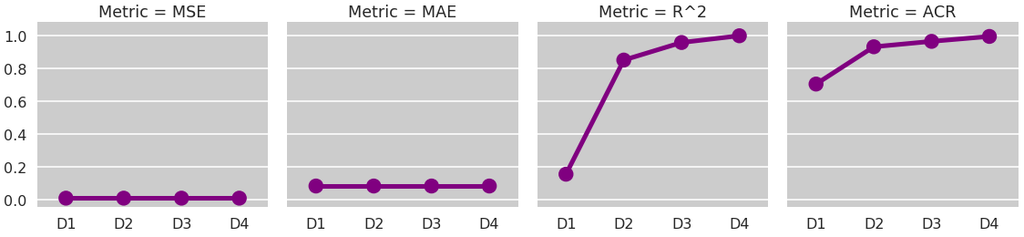

```python
data = [['MSE',D_MSE[0], D_MSE[1], D_MSE[2], D_MSE[3]],['MAE',D_MAE[0], D_MAE[1], D_MAE[2], D_MAE[3]],
        ['R^2',D_R2[0], D_R2[1], D_R2[2], D_R2[3]], ['ACR', D_Accuracy[0], D_Accuracy[1], D_Accuracy[2], D_Accuracy[3]]]
df = pd.DataFrame(data,columns=['Metric','D1', 'D2', 'D3', 'D4'])
print (np.round(df,3))
####################
with sns.axes_style("darkgrid", {"axes.facecolor": "0.8"}):
    sns.set_context("poster")
    sns.factorplot(data=np.round(df, 3), kind="point", col="Metric", color='purple')
```

# 2. Constant $R^2$ and Increasing MSE

In this part, We will again create 4 diferent data (D1, D2, D3, D4). We will apply $\frac{CoE}{CoV}$ rate as 1 for the D1, D2, D3, D4. That is mean; The CoE and CoV values will be 0.1, 1, 10, 100 for D1, D2, D3 and D4 respectively.

# Data1 (D1): $Y=0.1+0.1*X_1+0.1*X_2+0.1*X_3+(Random Error)$

While the constant number and CoV values are 0.1, and random error with te CoE=0.1 will be added.

# Data2 (D2): $Y=1+1*X_1+1*X_2+1*X_3+(Random Error)$

While the constant number and CoV values are 1, we will add the random errorwhich has CoE=1.

# Data3 (D3): $Y=10+10*X_1+10*X_2+10*X_3+(Random Error)$

While the constant number and CoV values are 10, we will add the random error which has the CoE=10.

# Data4 (D4): $Y=100+100*X_1+100*X_2+100*X_3+(Random Error)$

While the constant number and CoV values are 100, we will add the random error which has the CoE=100.

```python
input_dim = 3
output_dim = 1
size = 1000
total_size = size * input_dim
rand_state = np.random.RandomState(42)
X = np.array([rand_state.rand() for i in range(total_size)], dtype=np.float32)
X = X.reshape(-1, input_dim)
#coefficients
coeff=[]
alfa=[0.1, 1, 10, 100]
noise=[]
for i in alfa:coeff.append(np.array([1*i, 1*i, 1*i], dtype=np.float32))
```

```python
alfa=[0.1, 1, 10, 100]
noise=[]
rand_state = np.random.RandomState(42)
for i in alfa:noise.append(i*rand_state.normal(0,1,size))
```

```python
input_dim = 3
output_dim = 1
size = 1000
total_size = size * input_dim
rand_state = np.random.RandomState(42)
X = np.array([rand_state.rand() for i in range(total_size)], dtype=np.float32)
X = X.reshape(-1, input_dim)
#coefficients
coeff=[]
alfa=[0.1, 1, 10, 100]
noise=[]
for i in alfa:coeff.append(np.array([1*i, 1*i, 1*i], dtype=np.float32))
for i in alfa:
    rand_state = np.random.RandomState(42)
    noise.append(rand_state.normal(0,1,size)*i)
Y=[]
for i in range(0, len(coeff)):Y.append((X.dot(coeff[i]) + alfa[i] + noise[i]).reshape(-1, output_dim))
train_size = int(0.7*size)
X_train=[]
X_test=[]
Y_train=[]
Y_test=[]
LR=[]
Y_test_pred=[]
X_train_with_const=[]
for i in range(0, len(coeff)):
    X_train.append(X[:train_size])
    X_test.append(X[train_size:])
    Y_train.append(Y[i][:train_size])
    Y_test.append(Y[i][train_size:])
    X_train_with_const.append(sm.add_constant(X_train[i]) )
    LR.append(LinearRegression().fit(X_train[i], Y_train[i]))
    Y_test_pred.append(LR[i].predict(X_test[i]))
```

```python
Y_test_=[]
Y_test_pred_=[]
new=[]
for i in range(0, len(coeff)):
    Y_test_.append(pd.DataFrame(Y_test[i]))
    Y_test_pred_.append(pd.DataFrame(Y_test_pred[i]))
    new.append(pd.concat([Y_test_[i], Y_test_pred_[i]], axis=1, join='inner'))
    new[i].columns = ['actual', 'Predict']
```

```python
#for loop to calculate accuracy
Acr=[]
Accuracy=[]
for i in range(0,len(coeff)):
        Acr.append(new[i].iloc[0:301,].min(axis=1)/new[i].iloc[0:301,].max(axis=1))
        Accuracy.append(np.mean(Acr[i]))
```

```python
D_MSE=[]
D_MAE=[]
D_R2=[]
D_EVS=[]
D_Accuracy=[]
#calculate the metrics
for i in range (0, len(coeff)):
    D_MSE.append(metrics.mean_squared_error(Y_test_[i],Y_test_pred_[i]))
    D_MAE.append((metrics.mean_absolute_error(Y_test_[i],Y_test_pred_[i])))
    D_R2.append((metrics.r2_score(Y_test_[i],Y_test_pred_[i])))
    D_EVS.append((metrics.explained_variance_score(Y_test_[i],Y_test_pred_[i])))
    D_Accuracy.append(Accuracy[i])
```

```
  Metric     D1     D2      D3        D4
0    MSE  0.009  0.941  94.053  9405.268
1    MAE  0.078  0.777   7.773    77.734
2    R^2  0.144  0.144   0.144     0.144
3    ACR  0.738  0.738   0.738     0.738
```

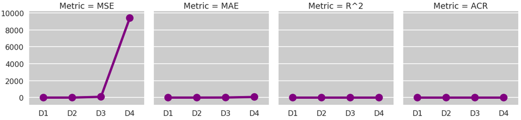

```python
data = [['MSE',D_MSE[0], D_MSE[1], D_MSE[2], D_MSE[3]],['MAE',D_MAE[0], D_MAE[1], D_MAE[2], D_MAE[3]],
        ['R^2',D_R2[0], D_R2[1], D_R2[2], D_R2[3]], ['ACR', D_Accuracy[0], D_Accuracy[1], D_Accuracy[2], D_Accuracy[3]]]
df = pd.DataFrame(data,columns=['Metric','D1', 'D2', 'D3', 'D4'])
print (np.round(df,3))
####################
with sns.axes_style("darkgrid", {"axes.facecolor": "0.8"}):
    sns.set_context("poster")
    sns.factorplot(data=np.round(df, 3), kind="point", col="Metric", color='purple')
```

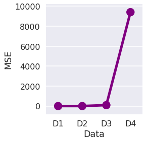

[figure not shown]

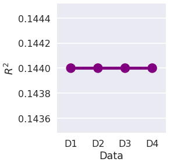

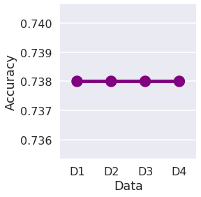

```python
with sns.axes_style("darkgrid"):
    sns.set_context("poster")
    MSE=sns.factorplot(data=np.round(df.iloc[0:1, 1:5], 3), kind="point", color='purple')
    MSE.set_axis_labels("Data", "MSE")
    MAE=sns.factorplot(data=np.round(df.iloc[0:1, 1:5], 3), kind="point", color='purple')
    MAE.set_axis_labels("Data", "MAE")
    R2=sns.factorplot(data=np.round(df.iloc[2:3, 1:5], 3), kind="point", color='purple')
    R2.set_axis_labels("Data", "$R^2$")
    ACR=sns.factorplot(data=np.round(df.iloc[3:4, 1:5], 3), kind="point", color='purple')
    ACR.set_axis_labels("Data", "Accuracy")
```

It can be seen from figure while MSE and MAE are increasing $R^2$ and **Accuracy** are constant. We applied $\frac{CoE}{CoV}$ rate as 1 for the D1, D2, D3, and D4. While CoE values for random error were increased, the $R^2$ and **Accuracy** did **not changed** due to **same $\frac{CoE}{CoV}=1$** for the D1, D2, D3, and D4.

# 3. Conclusion

The **analysis results** showed that, the $R^2$ and **Accuracy** values were in strong function of $\frac{CoE}{CoV}$ rate and there is no certain limitation for **MSE** to evaluate the regression models.

*Published: November 27, 2018*